# R Notebook

```r
library(tidyverse)
```

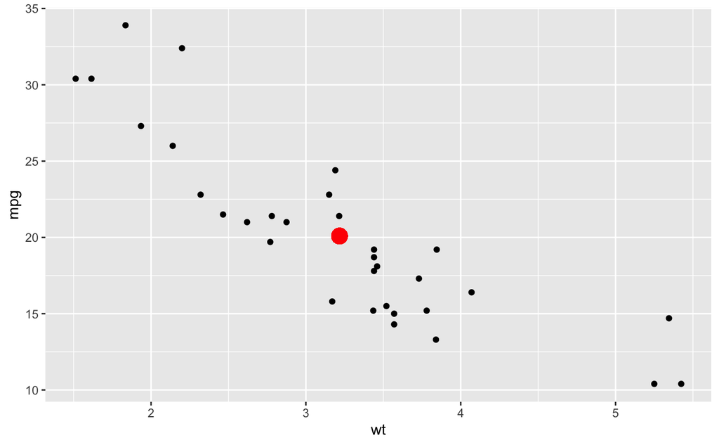

```r
mtcars %>%
  ggplot(aes(x = wt, y = mpg)) +
  geom_point() +
  geom_point(aes(x = mean(wt), y = mean(mpg)), col = "red", size = 5)
```

[figure not shown]

| cor(mpg, wt) |
| --- |
| -0.8676594 |

```r
# Pivot longer:
anscombe_long <- anscombe %>%
pivot_longer(everything(),
names_to = c(".value", "set"),
names_pattern = c("(\\D+)(\\d+)"))

# Group by set and get the correlation coefficient for each:
anscombe_long %>%
group_by(set) %>%
summarise(r = cor(x, y))
```

| set | r |
| --- | --- |
| 1 | 0.8164205 |
| 2 | 0.8162365 |
| 3 | 0.8162867 |
| 4 | 0.8165214 |

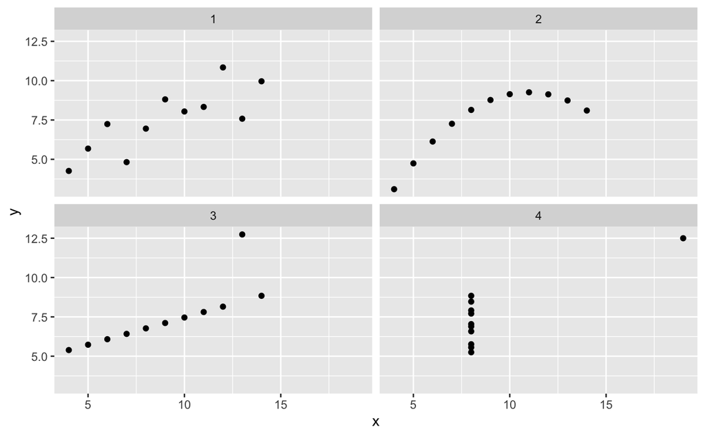

```r
# Plot the quartet:
anscombe_long %>%
ggplot() +
aes(x = x, y = y) +
geom_point() +
facet_wrap(~set)
```

[output not shown]

Task - 15 mins Let’s calculate correlation coefficients for various variables in the state.x77 dataset! Examine the contents of this dataset (try accessing documentation via ?state.x77 or running summary() on it). Choose a few combinations of variables to plot as y y versus x x and calculate the correlation coefficients for the same combinations. Do you find any strong correlations? Have a think about what kind of evidence you would need to be able to claim that any of the correlations you find are due to a causal relationship between the variables. [Hint the dataset is a matrix so convert it to a tibble first via tibble_states <- clean_names(as_tibble(state.x77)) to make manipulations easier].

| population | income | illiteracy | life_exp | murder | hs_grad | frost | area |
| --- | --- | --- | --- | --- | --- | --- | --- |
| 3615 | 3624 | 2.1 | 69.05 | 15.1 | 41.3 | 20 | 50708 |
| 365 | 6315 | 1.5 | 69.31 | 11.3 | 66.7 | 152 | 566432 |
| 2212 | 4530 | 1.8 | 70.55 | 7.8 | 58.1 | 15 | 113417 |
| 2110 | 3378 | 1.9 | 70.66 | 10.1 | 39.9 | 65 | 51945 |
| 21198 | 5114 | 1.1 | 71.71 | 10.3 | 62.6 | 20 | 156361 |
| 2541 | 4884 | 0.7 | 72.06 | 6.8 | 63.9 | 166 | 103766 |
| 3100 | 5348 | 1.1 | 72.48 | 3.1 | 56.0 | 139 | 4862 |
| 579 | 4809 | 0.9 | 70.06 | 6.2 | 54.6 | 103 | 1982 |
| 8277 | 4815 | 1.3 | 70.66 | 10.7 | 52.6 | 11 | 54090 |
| 4931 | 4091 | 2.0 | 68.54 | 13.9 | 40.6 | 60 | 58073 |

[output cut: 40 more lines]

| r |
| --- |
| -0.3321525 |

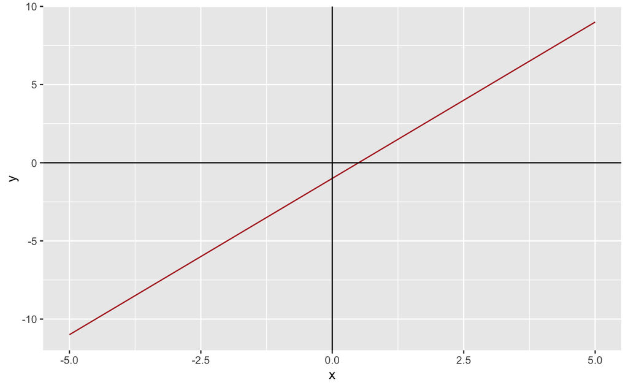

```r
line <-function(x,a,b){
  return(a*x +b )
}

data <- tibble(
  x = seq (-5, 5,0.1),
  y = line(x, a = 2, b = -1)
)

data %>%
  ggplot(aes(x, y))+
  geom_line(col = "firebrick")+
  geom_vline(xintercept = 0)+
  geom_hline(yintercept = 0)
```

Play around plotting two or three different lines. Try a line with a=0 a=0 and positive b. You can use mutate() to overwrite y in data from above Can we use our line() function to plot a perfectly vertical line?

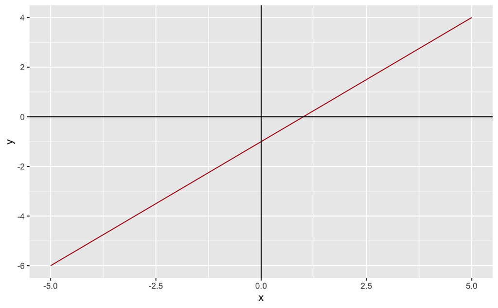

```r
data <- tibble(
  x = seq (-5, 5,0.1),
  y = line(x, a = 1, b = -1)
)

data %>%
  ggplot(aes(x, y))+
  geom_line(col = "firebrick")+
  geom_vline(xintercept = 0)+
  geom_hline(yintercept = 0)
```

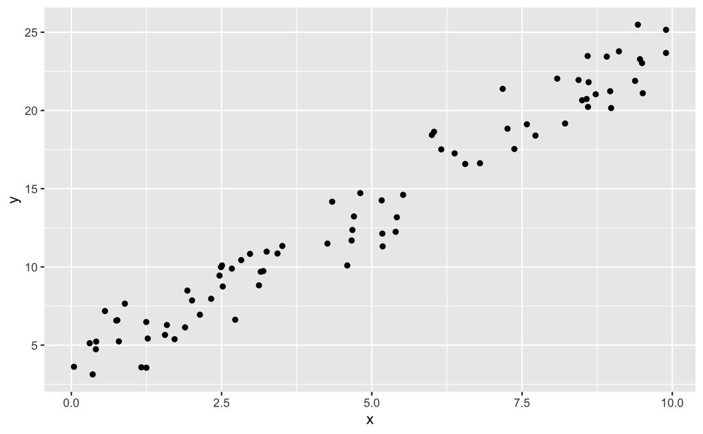

```r
noisy_line <- read_csv("data_3/noisy_line.csv")
noisy_line_plot <- noisy_line %>%
  ggplot(aes(x, y)) +
  geom_point()
noisy_line_plot
```

```r
centroid <- noisy_line %>%
  summarise(
    x = mean(x),
    y = mean(y)
  )
centroid
```

| x | y |
| --- | --- |
| 4.806482 | 13.44237 |

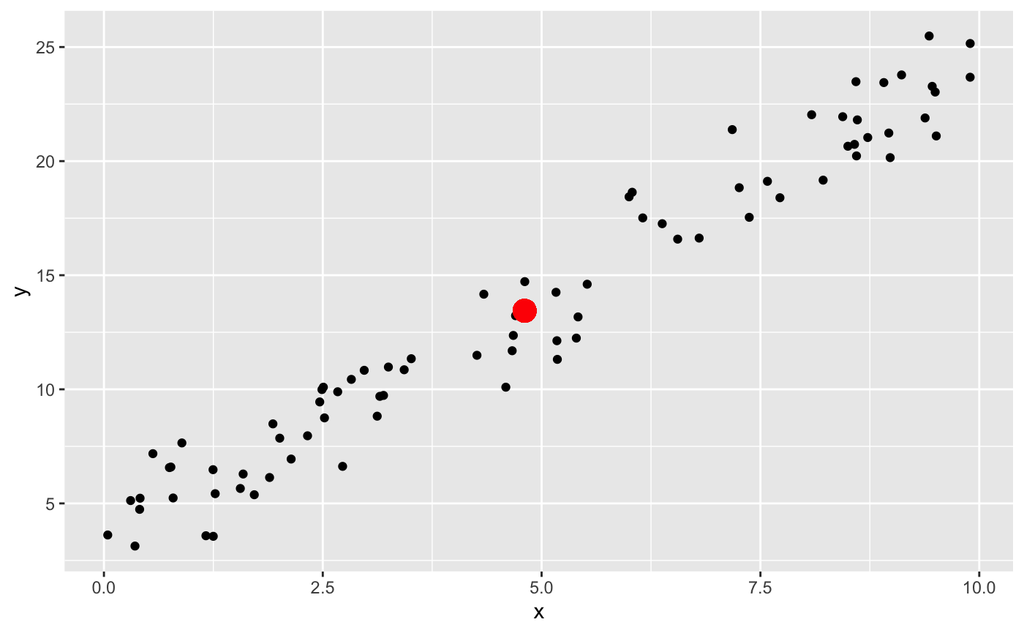

```r
noisy_line_plot <- noisy_line_plot +
  geom_point(aes(x = centroid$x, y = centroid$y), col = "red", size = 5)
noisy_line_plot
```

```r
get_intercept <- function (slope, centroid_x, centroid_y){
  return(centroid_y - slope* centroid_x)
}
```

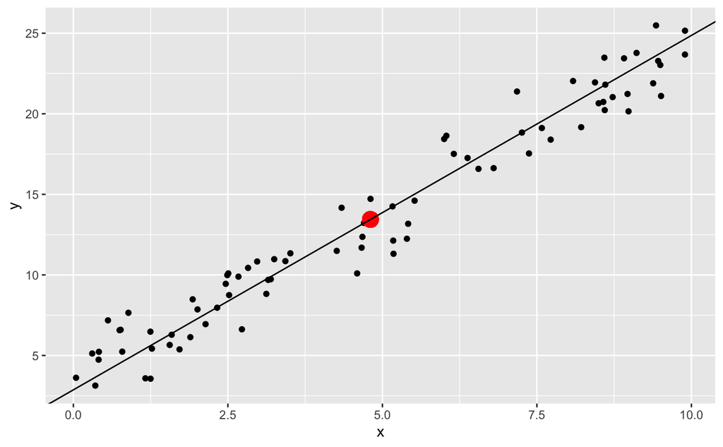

```r
slope = 2.2
noisy_line_plot +
  geom_abline(slope = slope, intercept = get_intercept(slope, centroid$x, centroid$y))
```

geom_smooth(method = “lm”, se = FALSE)